# Ozone foliar injury across time at NPS Units in the Cumberland Piedmont Inventory and Monitoring Network

Author

Alice Stears, alice_stears@partner.nps.gov

Published

October 26, 2026

# Background

When data were collected, data collectors recorded individuals with what they determined in the field to be ozone damage. We subsequently refer to these observations as “suspected ozone foliar injury.” Field crews then collected a voucher specimen consisting of three leaves from three individuals for each species in a plot that had foliar injury. These voucher specimens were then sent to an expert for verification of the cause of foliar injury. That status (positive or negative for foliar injury) is then assigned to all individuals of that species in that plot that the field crew suspected had foliar injury). We refer to foliar injury data after confirmation by an expert as “confirmed ozone foliar injury.”

```r
# determine confirmed ozone foliar injury
datVerified <- read.csv("../Data/cleanedDataPkgFiles/CUPN_OzoneFoliarInjury_SpeciesLeafCollected_CLEANED.csv") |>
  mutate(startDate = as_date(startDate)) |>
  # add a column indicating that these leaves are sent to the specialist (were identified as ozone damaged in the field)
  mutate(damageAmountCode_bin = 1)
# i think you should be able to just join by site, date, plot, and species...
datNew <- datAll |>
  full_join(datVerified)

# now, make a new column in the datNew data frame that gives the "confirmed ozone foliar injury"
datNew <- datNew |>
  mutate(confirmedOzoneInjury = ozoneInjuryReview) |>
  mutate(confirmedOzoneInjury = replace(confirmedOzoneInjury, confirmedOzoneInjury == "Positive", 1),
         confirmedOzoneInjury = replace(confirmedOzoneInjury, confirmedOzoneInjury == "Negative", 0),
         confirmedOzoneInjury = replace(confirmedOzoneInjury, is.na(confirmedOzoneInjury), 0),
         confirmedOzoneInjury = replace(confirmedOzoneInjury, confirmedOzoneInjury == "Inconclusive", 0.5))
```

Note that for the below plots, we only show information collected during “standard” plots (not “QA/QC”) do avoid double-sampling of individuals. Later in this document we compare data collection across these two types of sampling to assess accuracy.

# Exploratory figures

## Ozone Exposure Index for Vegetation

The Ozone exposure index for vegetation is the “3-month maximum 12-hour W126 index that occurs during the growing season (March–September), measured in parts per million-hours (ppm-hrs). The W126 index is a biologically relevant measure that preferentially weights the higher ozone concentrations more likely to cause plant damage.” This definition and the ozone index values come from the NPS Air Quality in Parks [website](https://www.nps.gov/subjects/air/park-conditions-trends.htm). [NPS benchmarks](https://www.nps.gov/articles/air-analysis-methods-latest.htm#section_3.2), which are based on EPA standards from 2014, indicate that ozone exposure index values below 7.0 ppm-hrs are “good,” values from 7.0-13.0 are “fair,” and values >13.0 are “poor”

There are yearly ozone index data collected on site for some park units. For others, there is an interpolated average index for each year, which interpolates values from nearby stations and then averages them over the previous five years (inclusive of the “current” year). For parks with on-site data collection, we also calculated a five year average index to allow us to compare values across all parks in the sampling protocol.

**NoteOzone exposure indices for vegetation across park units**

```r
# get the yearly data
ozoneDat_yearly <- ozoneDat |>
  filter(ozoneExposureIndexType == "yearly")

# calculate the 5-year moving average for each site
ozoneDat_yearlyTo5yr <- purrr::map(unique(ozoneDat_yearly$unitCode), .f = function(x) {
 ozoneDat_yearly |>
    filter(unitCode == x) |>
    mutate(
    movingAvgOzoneIndex = stats::filter(ts(ozoneExposureIndexForVegetation), filter = rep(1/5, 5), sides = 1  )
    )
} ) |>
    purrr::list_c() |>
  mutate(ozoneExposureIndexType = "average of previous 5 years inclusive of current year") |>
  select(-ozoneExposureIndexForVegetation) |>
  rename(ozoneExposureIndexForVegetation = movingAvgOzoneIndex) |>
  select(names(ozoneDat))

# add back into the ozone data frame
ozoneDat <- ozoneDat |>
  rbind(ozoneDat_yearlyTo5yr)

# make relevant info into ordered factors
ozoneDat <- ozoneDat |>
  mutate(ozoneDataCollectionType = factor(ozoneDataCollectionType, ordered = TRUE,
                                          levels = c("on-site sensor", "interpolated")),
         ozoneExposureIndexType = factor(ozoneExposureIndexType, ordered = TRUE,
                                          levels = c("yearly", "average of previous 5 years inclusive of current year")))

# save plotting info as variables
ozoneDataCollection_lu <- data.frame("ozoneDataCollectionType" = unique(ozoneDat$ozoneDataCollectionType),
                              "ozoneDataCollectionType_shape" = factor(c(16, 17), ordered = TRUE))
ozoneExposure_lu <- data.frame(
                              "ozoneExposureIndexType" = unique(ozoneDat$ozoneExposureIndexType),
                              "ozoneExposureIndexType_color" = factor(c("#009900FF", "#990099FF"), ordered = TRUE),
                              "ozoneExposureIndexType_plotName" = factor(c("Yearly", "Avg. over previous \n5 years"), ordered = TRUE))

ozoneDat <- ozoneDat |>
  left_join(ozoneDataCollection_lu) |>
  left_join(ozoneExposure_lu)

ribbonDat <- data.frame(
  "year" = c(2007, 2024, 2007, 2024, 2007, 2024),
  "type" = factor(c("good","good", "fair", "fair","poor","poor"),
                    levels = c("good", "fair", "poor")),
  "ymin" = c(0, 0, 7, 7, 13, 13),
  "ymax" = c(7, 7, 13, 13, max(ozoneDat[ozoneDat$year >2006,"ozoneExposureIndexForVegetation"], na.rm = TRUE),max(ozoneDat[ozoneDat$year >2006,"ozoneExposureIndexForVegetation"], na.rm = TRUE))
)
```

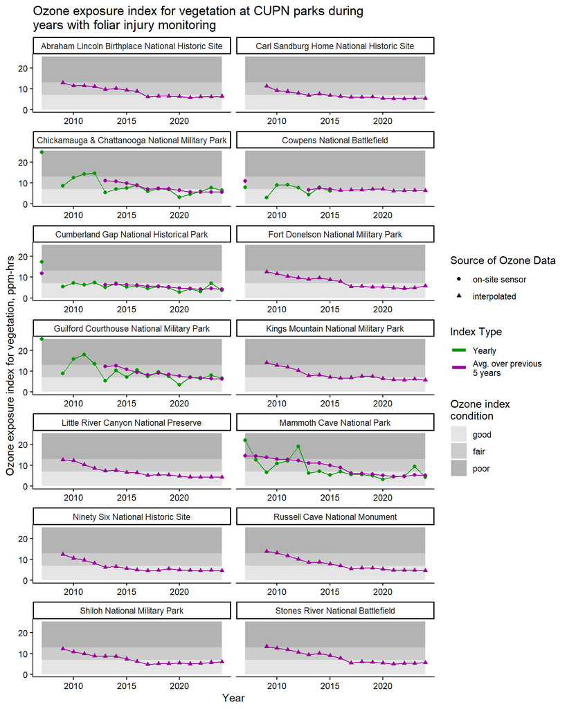

```r
# plot of number of individual plants w/ and without ozone by year across all park units
ozoneDat |>
  filter(year > 2006) |>
  ggplot() +
  facet_wrap(~unitName, ncol = 2, axes = "all_x") +
  geom_ribbon(data = ribbonDat, aes(ymin = ymin, ymax = ymax, x = year, fill = type)) +
  scale_fill_discrete(palette = c("grey90", "grey80", "grey70"), name = "Ozone index \ncondition") +
  geom_line(aes(x = year, y = ozoneExposureIndexForVegetation, col = ozoneExposureIndexType))+
  geom_point(aes(x = year, y = ozoneExposureIndexForVegetation, col = ozoneExposureIndexType, pch = ozoneDataCollectionType)) +
  xlim(2007, NA) +
  scale_color_discrete(labels = as.character(unique(ozoneDat$ozoneExposureIndexType_plotName)) , name = "Index Type", palette = as.character(unique(ozoneDat$ozoneExposureIndexType_color)),
                       guide = guide_legend(override.aes = list(pch = NA, linewidth = 1.5))) +
  scale_shape_manual(name = "Source of Ozone Data", values = as.integer(as.character(unique(ozoneDat$ozoneDataCollectionType_shape)))) +
  labs(title = "Ozone exposure index for vegetation at CUPN parks during \nyears with foliar injury monitoring",
       x = "Year", y = "Ozone exposure index for vegetation, ppm-hrs")
```

## Ozone foliar injury rates

In the following figures, we show suspected and confirmed ozone foliar injury at all of the CUPN parks across the monitoring interval. We show the presence of foliar injury (i.e. number of individuals with and without injury) and the rate of foliar injury (i.e. proportion of total observed individuals with and without injury). We also show the presence and rate of ozone injury by severity. Each of these metrics is shown grouped across all parks and all species, groups across all parks by species, grouped across all species in a park, and by species in a park.

## Presence and rate of *suspected* ozone foliar injury across all parks across time…

**Note… across all species**

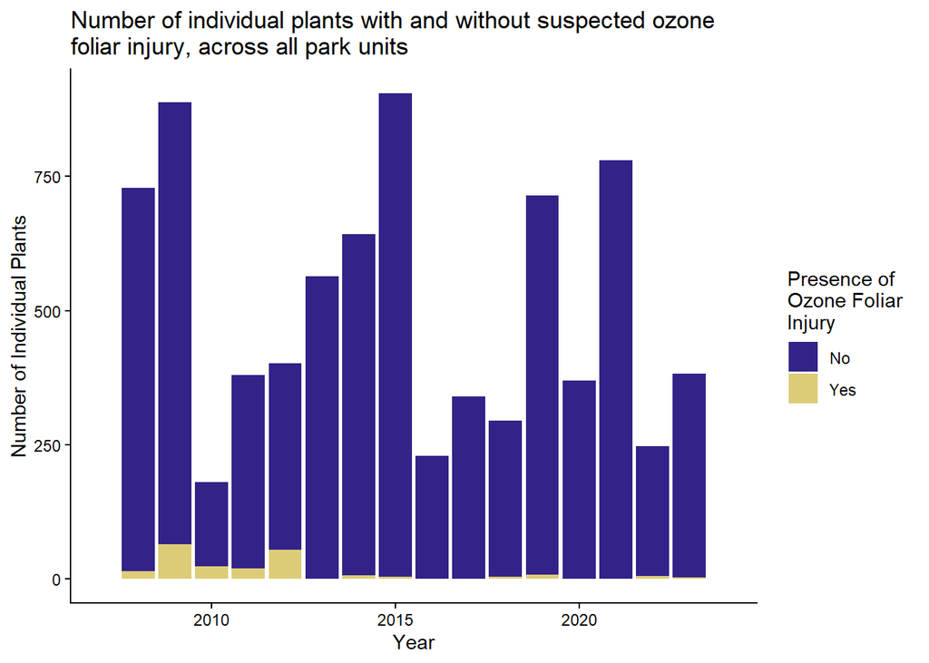

```r
# trim the data to only have observations from 'standard plots' (not QA/QC plots)
datAll_std <- datNew |>
  filter(eventType == "ozone standard") |>
  mutate(confirmedOzoneInjury = factor(confirmedOzoneInjury, ordered = TRUE, levels = c(0, 1, 0.5))) |>
  mutate(damageAmountCode_bin = factor(damageAmountCode_bin, ordered = TRUE, levels = c(0, 1, 0.5)))


# plot of number of individual plants w/ and without ozone by year across all park units
datAll_std |>
  ggplot() +
  geom_bar(aes(x = as.integer(year), fill = as.factor(damageAmountCode_bin)), width = 0.9) +
  guides(fill = guide_legend("Presence of \nOzone Foliar \nInjury")) +
  theme(palette.fill.discrete = c("#332288", "#DDCC77", "#44AA99")) +
  scale_fill_discrete(labels = c("No", "Yes", "Inconclusive")) +
  labs(x = "Year", y = "Number of Individual Plants",
        title = "Number of individual plants with and without suspected ozone \nfoliar injury, across all park units")+
     xlim(c(min(datAll$year)-1, max(datAll$year)+1))
```

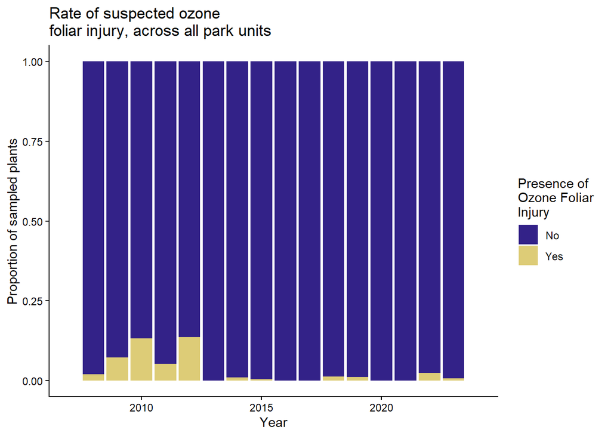

```r
# plot of proportion of individual plants w/ and without ozone by year across all park units
datAll_std |>
  #group_by(year, damageAmountCode_bin) |>
  #summarize(n = length(year))
  ggplot() +
  geom_bar(aes(x = as.integer(year), fill = as.factor(damageAmountCode_bin)), position = "fill", width = 0.9) +
  guides(fill = guide_legend("Presence of \nOzone Foliar \nInjury")) +
  theme(palette.fill.discrete = c("#332288", "#DDCC77", "#44AA99")) +
  scale_fill_discrete(labels = c("No", "Yes", "Inconclusive")) +
  labs(x = "Year", y = "Proportion of sampled plants",
        title = "Rate of suspected ozone \nfoliar injury, across all park units")+
     xlim(c(min(datAll$year)-1, max(datAll$year)+1))
```

**Note… by species**

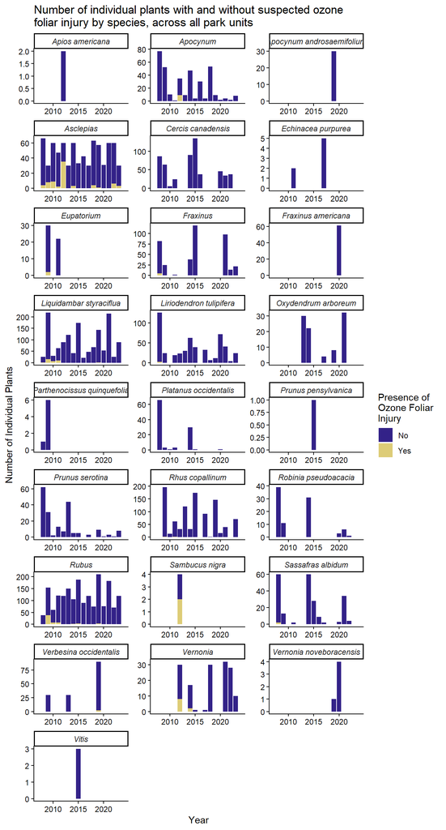

```r
# plot of number of individual plants w/ and without ozone by year across all park units
datAll_std |>
  ggplot() +
  facet_wrap(~scientificName, scales = "free_y", ncol = 3, axes = "all_x") +
  geom_bar(aes(x = as.integer(year), fill = as.factor(damageAmountCode_bin)), width = 0.9) +
  guides(fill = guide_legend("Presence of \nOzone Foliar \nInjury")) +
  theme(palette.fill.discrete = c("#332288", "#DDCC77", "#44AA99"),
        strip.text = element_text(face = "italic")) +
  scale_fill_discrete(labels = c("No", "Yes", "Inconclusive")) +
  labs(x = "Year", y = "Number of Individual Plants",
        title = "Number of individual plants with and without suspected ozone \nfoliar injury by species, across all park units")+
     xlim(c(min(datAll$year)-1, max(datAll$year)+1))
```

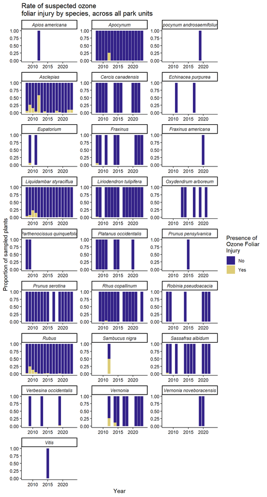

```r
# plot of proportion of individual plants w/ and without ozone by year across all park units
datAll_std |>
  #group_by(year, damageAmountCode_bin) |>
  #summarize(n = length(year))
  ggplot() +
  facet_wrap(~scientificName, scales = "free_y", ncol = 3, axes = "all_x") +
  geom_bar(aes(x = as.integer(year), fill = as.factor(damageAmountCode_bin)), position = "fill", width = 0.9) +
  guides(fill = guide_legend("Presence of \nOzone Foliar \nInjury")) +
  theme(palette.fill.discrete = c("#332288", "#DDCC77", "#44AA99"),
        strip.text = element_text(face = "italic")) +
  scale_fill_discrete(labels = c("No", "Yes", "Inconclusive")) +
  labs(x = "Year", y = "Proportion of sampled plants",
        title = "Rate of suspected ozone \nfoliar injury by species, across all park units")+
     xlim(c(min(datAll$year)-1, max(datAll$year)+1))
```

## Presence and rate of *suspected* ozone foliar injury by park unit across time…

**Note… across all species**

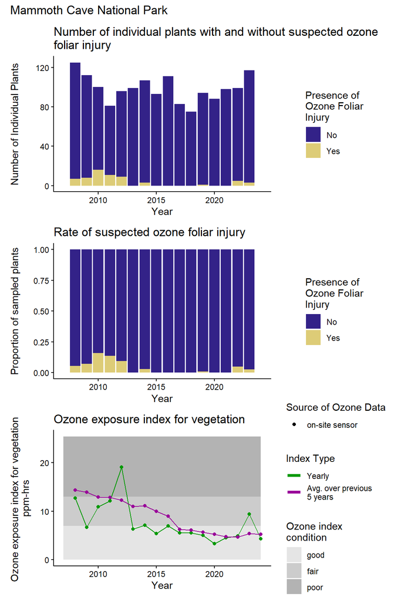

```r
parkNames <- unique(datAll_std$unitName)
suspectedOzoneFigsByPark <- vector(length = length(parkNames), mode = "list")
for (i in seq_along(parkNames)) {
  numOzone_i <- datAll_std |>
    filter(unitName == parkNames[i]) |>
  ggplot() +
  #facet_wrap(~unitName, ncol = 2, axes = "all_x", scales = "free_y") +
  geom_bar(aes(x = as.integer(year), fill = as.factor(damageAmountCode_bin)), width = 0.9) +
  guides(fill = guide_legend("Presence of \nOzone Foliar \nInjury")) +
  theme(palette.fill.discrete = c("#332288", "#DDCC77", "#44AA99")) +
  scale_fill_discrete(labels = c("No", "Yes", "Inconclusive")) +
  labs(x = "Year", y = "Number of Individual Plants",
        title = "Number of individual plants with and without suspected ozone \nfoliar injury")+
     xlim(c(min(datAll$year)-1, max(datAll$year)+1))


# plot of proportion of individual plants w/ and without ozone by year across all park units
rateOzone_i <- datAll_std |>
    filter(unitName == parkNames[i]) |>
  ggplot() +
  #facet_wrap(~unitName, ncol = 2, axes = "all_x", scales = "free_y") +
  geom_bar(aes(x = as.integer(year), fill = as.factor(damageAmountCode_bin)), position = "fill", width = 0.9) +
  guides(fill = guide_legend("Presence of \nOzone Foliar \nInjury")) +
  theme(palette.fill.discrete = c("#332288", "#DDCC77", "#44AA99")) +
  scale_fill_discrete(labels = c("No", "Yes", "Inconclusive")) +
  labs(x = "Year", y = "Proportion of sampled plants",
        title = "Rate of suspected ozone foliar injury")+
     xlim(c(min(datAll$year)-1, max(datAll$year)+1))

# plot of ozone indices
ozoneDat_i <- ozoneDat |>
  filter(unitName == parkNames[i]) |>
  filter(year > 2007)
ozone_i <- ozoneDat_i |>
  ggplot() +
  geom_ribbon(data = ribbonDat, aes(ymin = ymin, ymax = ymax, x = year, fill = type)) +
  scale_fill_discrete(palette = c("grey90", "grey80", "grey70"), name = "Ozone index \ncondition") +
  #facet_wrap(~unitName, ncol = 2) +
  geom_line(aes(x = year, y = ozoneExposureIndexForVegetation, col = ozoneExposureIndexType))+
  geom_point(aes(x = year, y = ozoneExposureIndexForVegetation, col = ozoneExposureIndexType, pch = ozoneDataCollectionType)) +
     xlim(c(min(datAll$year)-1, max(datAll$year)+1))+
    scale_color_discrete(labels = as.character(unique(ozoneDat$ozoneExposureIndexType_plotName)) , name = "Index Type", palette = as.character(unique(ozoneDat$ozoneExposureIndexType_color)),
                       guide = guide_legend(override.aes = list(pch = NA, linewidth = 1.5))) +
  scale_shape_manual(name = "Source of Ozone Data", values = as.integer(as.character(unique(ozoneDat$ozoneDataCollectionType_shape)))) +
  labs(title = "Ozone exposure index for vegetation",
       x = "Year", y = "Ozone exposure index for vegetation \nppm-hrs")

  suspectedOzoneFigsByPark[[i]] <- (numOzone_i / rateOzone_i / ozone_i) + patchwork::plot_annotation(title = parkNames[i])
}

  suspectedOzoneFigsByPark[[1]]
```

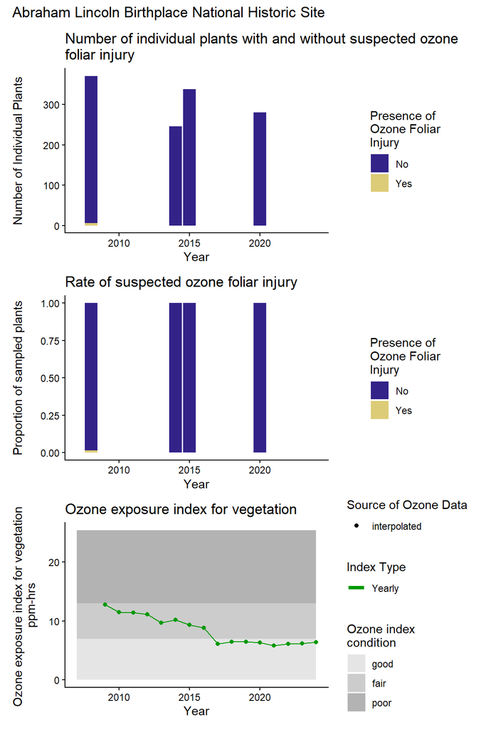

```r
  suspectedOzoneFigsByPark[[2]]
```

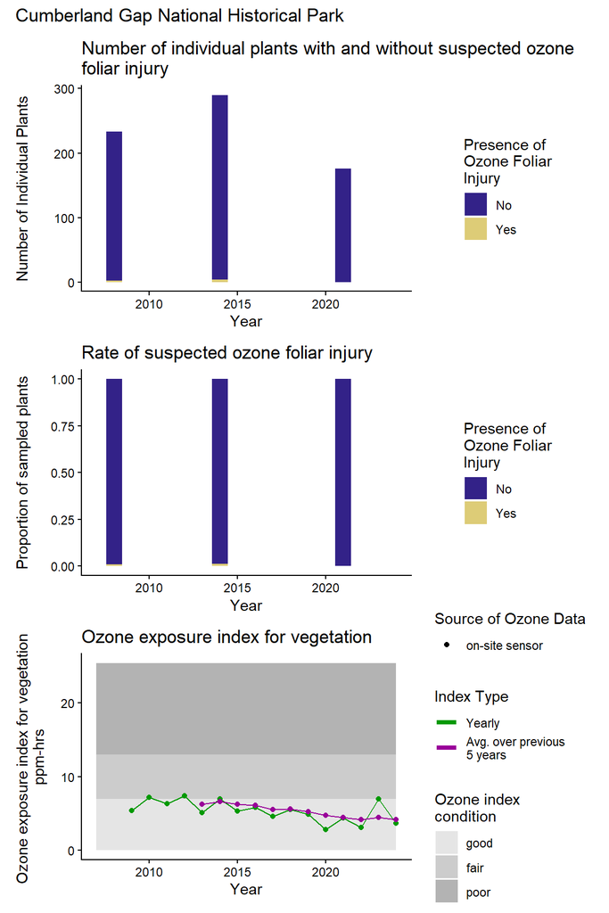

```r
  suspectedOzoneFigsByPark[[3]]
```

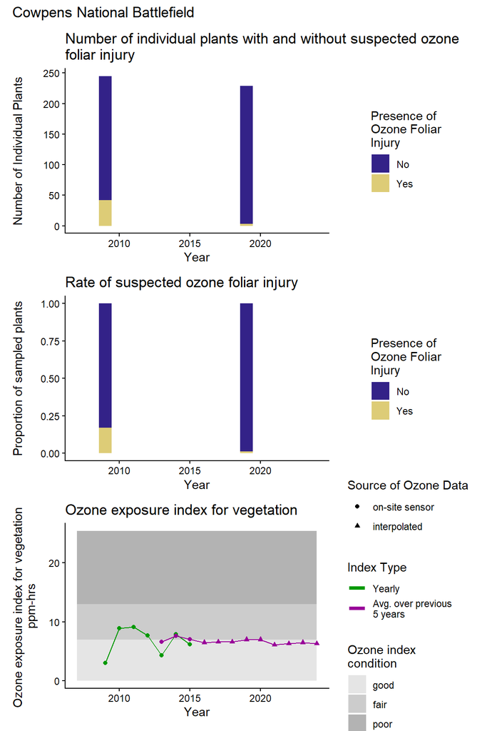

```r
  suspectedOzoneFigsByPark[[4]]
```

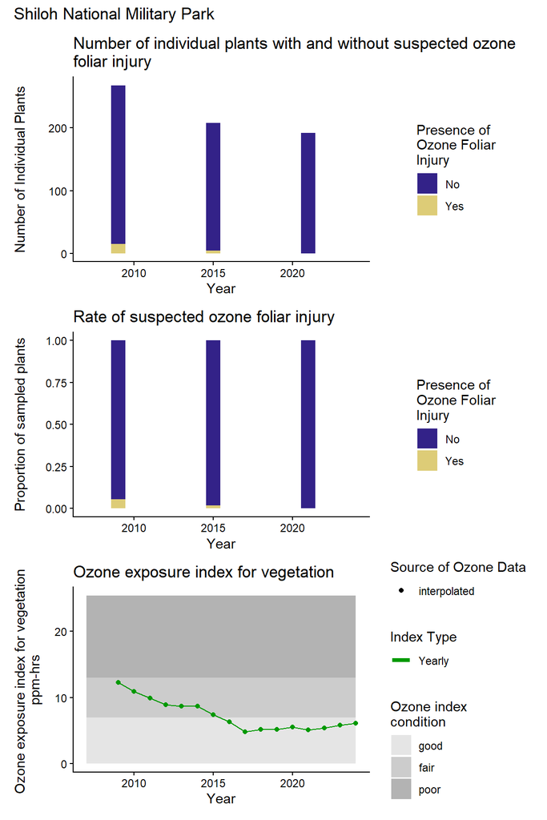

```r
  suspectedOzoneFigsByPark[[5]]
```

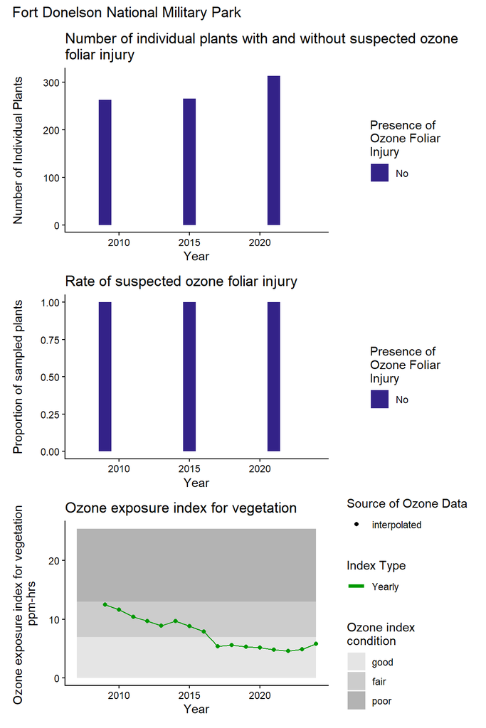

```r
  suspectedOzoneFigsByPark[[6]]
```

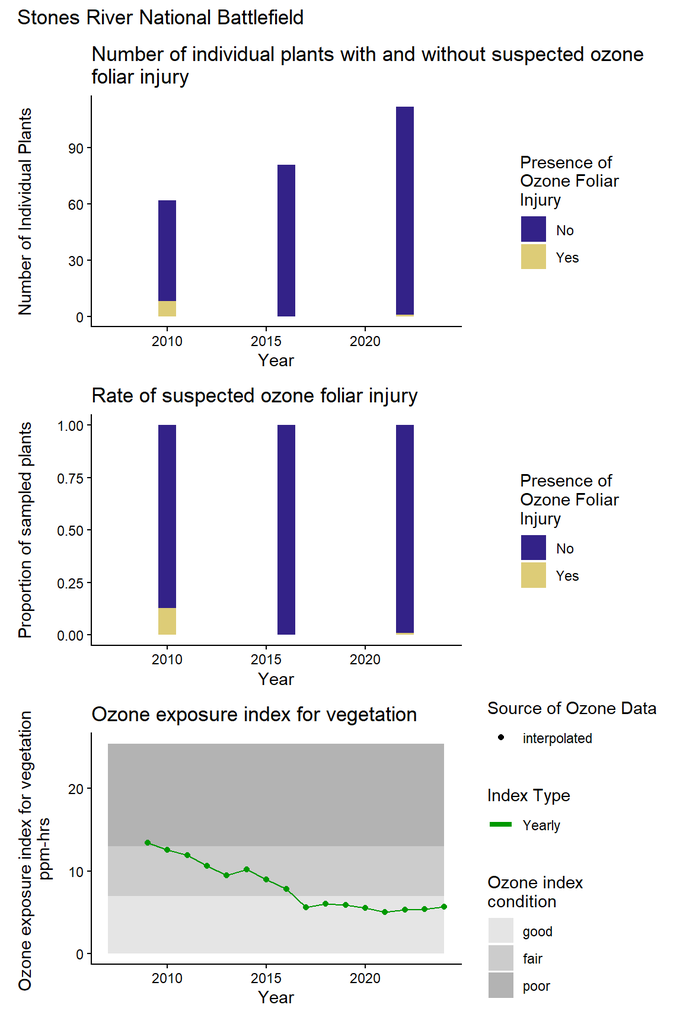

```r
  suspectedOzoneFigsByPark[[7]]
```

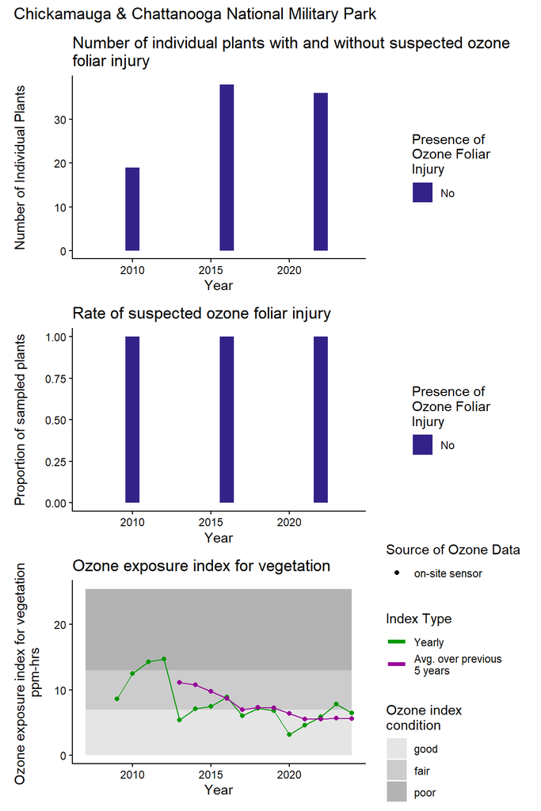

```r
  suspectedOzoneFigsByPark[[8]]
```

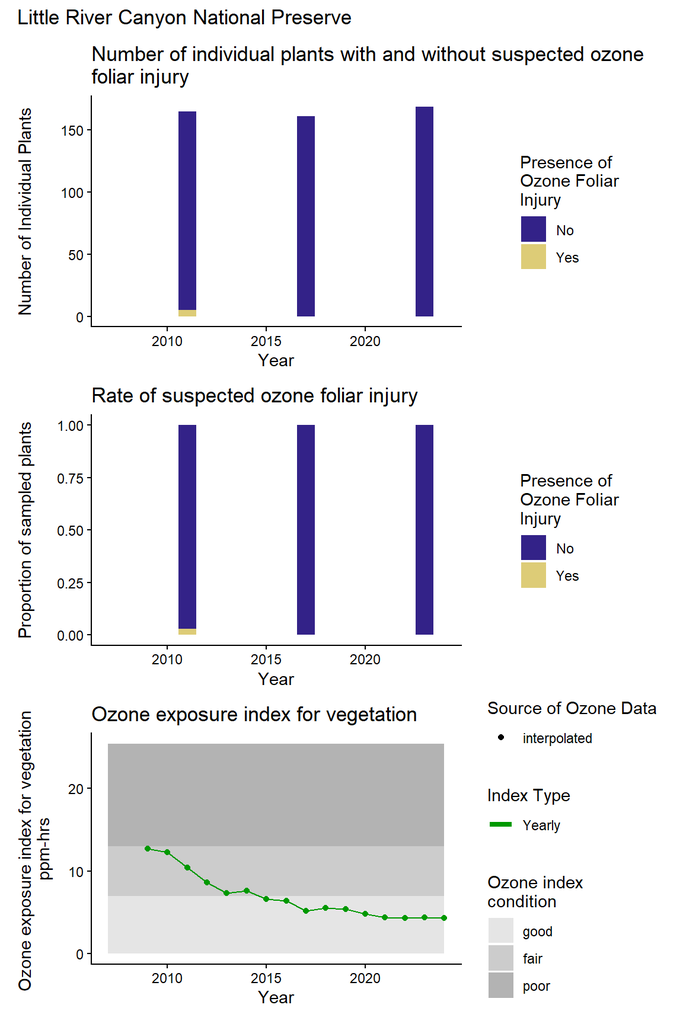

```r
  suspectedOzoneFigsByPark[[9]]
```

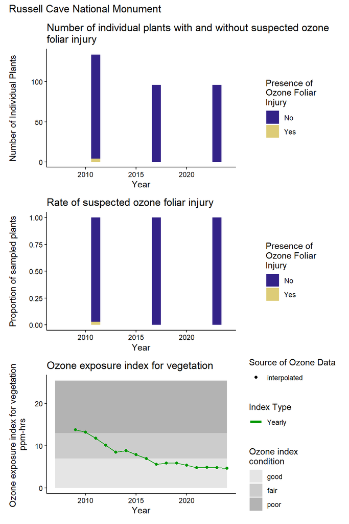

```r
  suspectedOzoneFigsByPark[[10]]
```

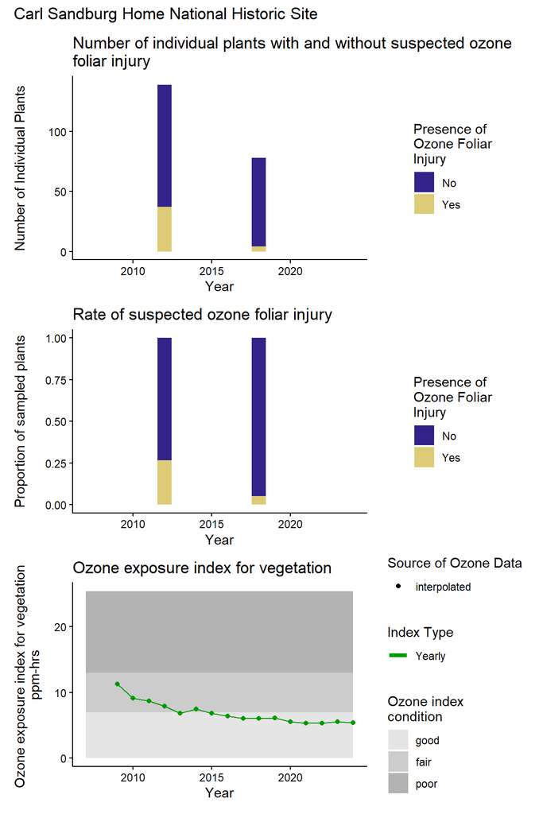

```r
  suspectedOzoneFigsByPark[[11]]
```